# Risk of advanced respiratory support or death in hospitalized subjects with acute viral respiratory illness

A multistate model analysis

João Carmezim, Cristian Tebé, Natàlia Pallarès, Guadalupe Gómez-Melis, Mireia Besalú

September 30, 2026

## About me

my path so far

2013 - 2018

BSc in Biology

Universidade do Porto

2018 - 2020

MSc in Biostatistics

Universitat de València

2021 - present

Biostatistician

Bellvitge Biomedical Research Institute (IDIBELL) & Germans Trias i Pujol Research Institute and Hospital (IGTP)

Dec 2025

PhD candidate officially started

Statistics & Operations Research - UPC

PhD focus

Multistate models beyond first-order Markov: clinical trajectories of hospitalised patients

Day-to-day

Statistical support for clinical research; survival analysis; Shiny apps for prediction

## Index

running order

- Background & objectives
- Methods: data and multistate models
- Results
- Checking the model: the Markov assumption
- Limitations & future work
- Take-home messages

## Background

acute respiratory infections

- **Acute respiratory infections (ARIs)**, such as COVID-19 and influenza, cause seasonal challenges to healthcare systems worldwide, ranging from mild disease to life-threatening complications.

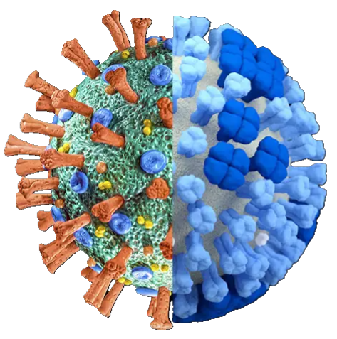

According to WHO estimates, approximately 116.5 million cases of COVID-19 were reported globally in 2023, and 3 to 5 million cases of severe influenza occur every year.

- **Known prognostic factors**: age, sex, comorbidities (COPD, cardiovascular and chronic kidney disease) and country income, with higher ICU admission and in-hospital death in low- and middle-income countries.
- Hospitalisation for an ARI is a **multi-step process**: patients escalate through levels of respiratory support and recover, all within one admission. Predicting these steps is key to **anticipate hospital resources**.

## Objectives

what we wanted to find out

- **Hypothesis**

  Clinical factors already known **at admission** (age, sex, comorbidities, where the patient is treated) predict the different steps of the clinical trajectory of patients hospitalised with an ARI.
- **Objectives**
  1. Measure how each factor affects **each step** of the hospital journey, not just the final outcome.
  2. Turn those results into easy-to-read **probabilities** and **risk profiles** (e.g. “chance of death within 28 days”).
  3. Share the predictions through an **interactive web app**, to help hospitals anticipate **how much respiratory support they will need** (NIV/HFNC, MV/ECMO).

# Methods

## STRIVE Cohort

- International **prospective multicentre** observational cohort (FLU 003 Plus - NCT01056185).
- Run by the **INSIGHT** network within the *Strategies and Treatments for Respiratory Infections and Viral Emergencies* (**STRIVE**) group.
- **Inclusion**: adults (≥18 y) admitted to hospital with confirmed or suspected **influenza** or **COVID-19**, written informed consent.
- Recruitment: Influenza **2013-2024**, COVID-19 **2020-2024**.
- Collected: demographics, comorbidities, laboratory results, clinical outcomes, and **start/end dates of clinical states**.

13

countries

69

sites

5461

patients recruited

2013-24

recruitment window

## From survival analysis to multistate models

the Cox model: one event

$$h(t \mid X) \;=\; h_{0}(t)\,e^{\beta^{\top} X}$$

- $h(t \mid X)$: **hazard**, the instantaneous risk of the event at time $t$ for a patient with characteristics $X$.
- $h_{0}(t)$: **baseline hazard**, the risk for a reference patient.
- $e^{\beta}$: **hazard ratio (HR)**, how much a characteristic multiplies that risk.
- Appropriate when there is **a single event** of interest (e.g. death).

## One admission, many journeys

why a single endpoint is not enough

[figure not shown]

**Classic survival analysis** looks only at the final state: *alive or dead, and when*.

**A multistate model** uses the **whole path**: every step, its order and its timing.

## The multistate model

one Cox model per transition

[figure not shown]

Advanced support discharge = support withdrawn, patient still in hospital

$$h_{k}(t \mid X) \;=\; h_{0k}(t)\,e^{\beta_{k}^{\top} X}, \quad k = 1,\ldots,11$$

- **6 clinical states** and **11 possible transitions** between them.
- Each transition $k$ has its **own hazard** $h_k$, with its own baseline $h_{0k}$ and **its own covariate effects** $\beta_k$.
- A factor (e.g. age) can matter for **one transition** and not for another.
- Discharge and death are **absorbing states**.
- **Markov assumption**: the next transition depends only on the **current state**. *Tested later.*

## From hazards to probabilities

how to read the results

1: Hazard ratio (HR) - one transition

Compares the risk of **one transition** between two groups.  
HR = 2 → twice the risk; HR = 1 → no difference; HR = 0.5 → half the risk

2: State-occupation probability - all transitions

Combines **all 11 transition hazards** (Aalen-Johansen estimator) to answer:  
*“What is the probability that a patient like this has died by day 28?”*

$$\pi_j(t) \;=\; \Pr\{S(t)=j \mid S(0)=1\}$$

probability of being in state j at day t, for a patient admitted at day 0 (state 1)

- Calculated for **risk profiles** (disease, age, sex, comorbidities, country income), with **95% confidence intervals**.

## Statistical analysis

R - mstate

- **Prognostic factors** chosen *a priori* with infectious-disease clinicians: disease (flu / COVID-19), age, sex, COPD, cardiovascular disease (CVD), chronic kidney disease (CKD), country income (HIC vs LMIC).
- **One Cox model stratified by transition**: a separate baseline hazard for each transition, and covariate effects specific to each transition. Time = days since admission.
- **Proportional hazards** checked (Schoenfeld residuals): when violated, the covariate was **stratified** in that transition; when events were too few, it was **omitted** from that transition.
- **Markov assumption** tested for each transition (Titman-Putter test).
- **Risk profiles**: all combinations with ≥5 patients and ≥1 event, ranked by the peak predicted probability within 28 days.
- All analyses in **R** (*mstate*); interactive **Shiny** app.

# Results

## Flowchart

[figure not shown]

## Patient profile

| **Variables** | Influenza n = 3216 | COVID-19 n = 1752 |
| --- | --- | --- |
| **Age, median [Q1; Q3]** | 61.5 [46; 74] | 61.9 [48; 74] |
| **Sex at birth** |  |  |
| Male | 48.5 % | **58.6 %** |
| Female | **51.5 %** | 41.4 % |
| **Country income** |  |  |
| HIC | 72.1 % | 41.4 % |
| LMIC | 27.9 % | **58.6 %** |
| **COPD** | **16.0 %** | 8.1 % |
| **Cardiovascular disease¹** | 22.6 % | 18.6 % |
| **Chronic kidney disease** | 9.2 % | 4.8 % |
| **Diabetes** | 19.9 % | 17.8 % |

¹ Excluding hypertension.

## Observed transitions

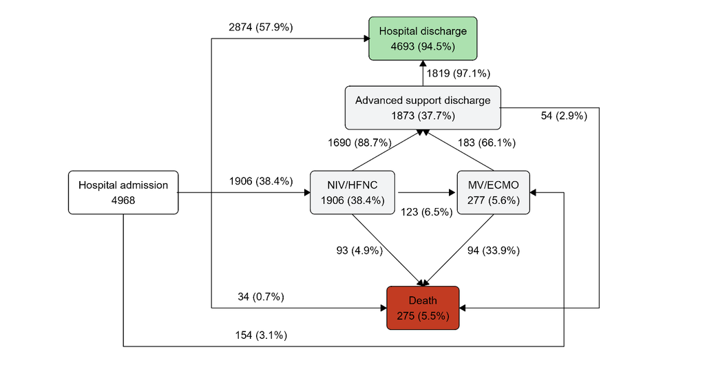

57.9%

discharged without advanced support

38.4%

needed NIV/HFNC

5.6%

needed MV/ECMO

5.5%

died in hospital

## Which factors matter at each step?

hazard ratios - HR > 1 higher risk - HR < 1 lower risk - bold = statistically significant

**Admission → NIV/HFNC**

|  | HR [95% CI] |
| --- | --- |
| Age (per 5 y) | **1.09** [1.07-1.10] |
| LMIC (vs HIC) | **0.74** [0.67-0.82] |
| COPD | **1.65** [1.46-1.85] |
| CVD | 0.96 [0.85-1.07] |

**NIV/HFNC → Death**

|  | HR [95% CI] |
| --- | --- |
| Age (per 5 y) | **1.48** [1.33-1.65] |
| COVID-19 (vs influenza) | 1.14 [0.72-1.81] |
| LMIC (vs HIC) | **3.36** [1.99-5.67] |
| COPD | 0.79 [0.47-1.35] |

Admission → NIV/HFNC: respiratory disease and sex did not meet the proportional hazards assumption and were stratified (no HR estimated).

**COPD** pushes patients onto NIV/HFNC but not towards death; patients in **low/middle-income countries (LMIC)** are put on NIV/HFNC less often, but die more often once on it.

## Who dies once on NIV/HFNC?

Predicted probability by risk profile - highest vs lowest

Death within 28 days of starting NIV/HFNC

▲ Highest risk

COVID

Age ≥70, Male, Low- & Middle-income country

With COPD, with CVD, no CKD

≥12.5%8.3-16.7

2/8

INFLU.

Age ≥70, Male, Low- & Middle-income country

With COPD, with CVD, no CKD

≥10.1%6.8-13.3

1/10

▼ Lowest risk

COVID

Age 60-70, Male, High-income country

No COPD, no CVD, no CKD

≥3.2%2.1-4.4

1/49

INFLU.

Age ≥70, Female, High-income country

No COPD, no CVD, no CKD

≥3.5%2.5-4.5

2/52

**COPD** = Chronic obstructive pulmonary disease; **CVD** = Cardiovascular disease; **CKD** = Chronic kidney disease; **obs** = Observed events / N; **Profiles shown**: ≥5 patients and ≥1 observed event, model-based peak estimate (95% pointwise CI) at the age-group boundary, counts among patients who received NIV/HFNC

## Death after starting NIV/HFNC

Cumulative incidence of death - days since starting NIV/HFNC

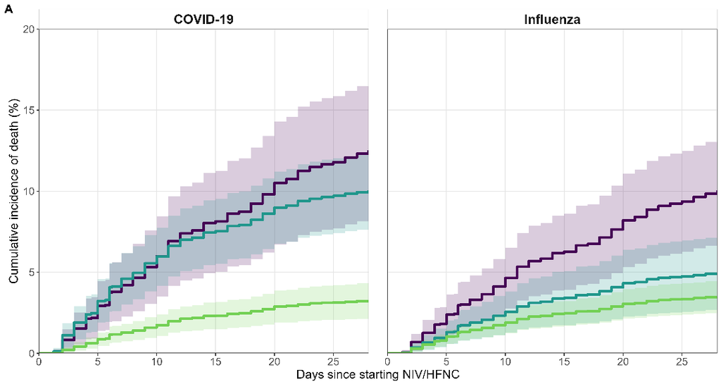

**COVID-19** Highest: 70 y, male, LMIC, COPD + CVD Median: 70 y, female, LMIC, no comorbidities Lowest: 60 y, male, HIC, no comorbidities  
**Influenza** Highest: 70 y, male, LMIC, COPD + CVD Median: 70 y, female, HIC, CVD + CKD Lowest: 70 y, female, HIC, no comorbidities  
Shaded bands: 95% confidence intervals

## Who dies within 28 days of admission?

Predicted probability by risk profile - highest vs lowest

Death within 28 days of hospital admission

▲ Highest risk

COVID

Age ≥70, Male, Low- & Middle-income country

No COPD, with CVD, with CKD

≥12.9%8.5-17.3

1/8

INFLU.

Age ≥70, Male, Low- & Middle-income country

With COPD, with CVD, no CKD

≥7.1%4.8-9.3

4/20

▼ Lowest risk

COVID

Age 60-70, Female, High-income country

No COPD, no CVD, no CKD

≥1.7%1.1-2.3

1/46

INFLU.

Age ≤50, Female, High-income country

No COPD, no CVD, no CKD

≤0.7%0.4-0.9

6/345

**COPD** = Chronic obstructive pulmonary disease; **CVD** = Cardiovascular disease; **CKD** = Chronic kidney disease; **obs** = Observed events / N; **Profiles shown**: ≥5 patients and ≥1 observed event, model-based peak estimate (95% pointwise CI) at the age-group boundary, counts among all patients with that disease

## Death from hospital admission

Cumulative incidence of death - days since hospital admission

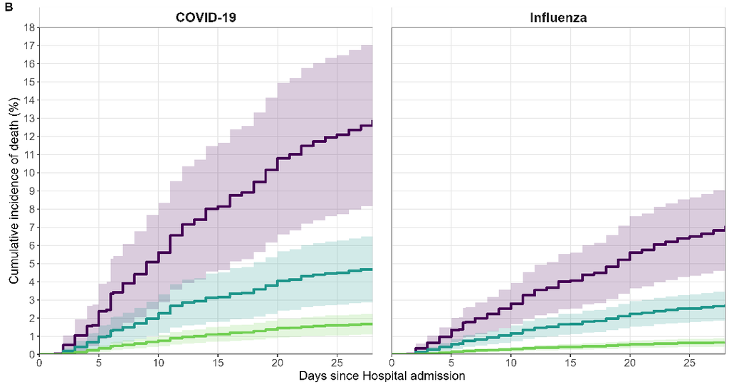

**COVID-19** Highest: 70 y, male, LMIC, CVD + CKD Median: 70 y, male, HIC, COPD Lowest: 60 y, female, HIC, no comorbidities  
**Influenza** Highest: 70 y, male, LMIC, COPD + CVD Median: 70 y, male, HIC, CVD Lowest: 50 y, female, HIC, no comorbidities  
Shaded bands: 95% confidence intervals

## Risk profiles: Shiny app

App: [brui.shinyapps.io/STRIVE](https://brui.shinyapps.io/STRIVE/) Source code: github.com/jcarmezim/STRIVE-ShinyAPP

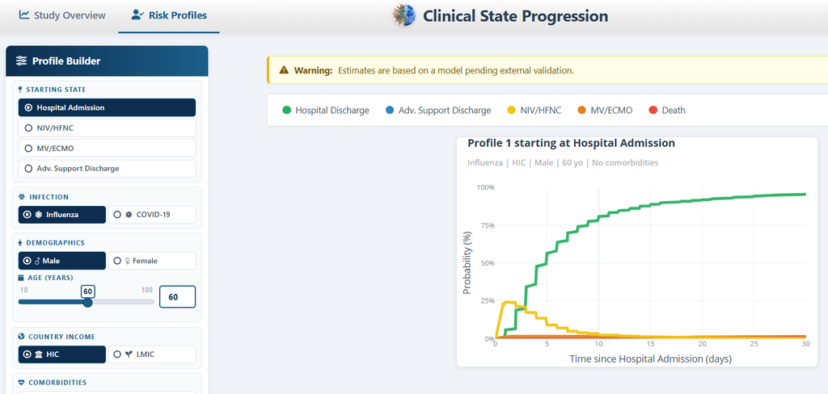

Intended to anticipate **aggregate care demand** (NIV/HFNC, MV/ECMO capacity), not to guide the management of a single patient.

# Checking the model

## Does the patient’s history matter?

the Markov assumption

## Testing the Markov assumption

Titman-Putter test - NIV/HFNC → MV/ECMO

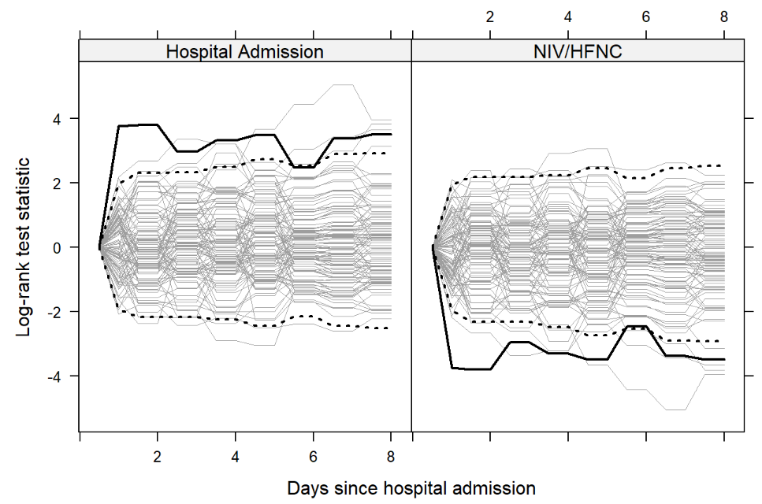

5 / 11

transitions violate the Markov assumption

Black line = observed test statistic; dotted lines = expected range if the assumption holds.  
Violations: NIV/HFNC → MV/ECMO; NIV/HFNC → Adv. support discharge; MV/ECMO → Adv. support discharge; MV/ECMO → Death; **Adv. support discharge → Hospital discharge** (strongest)

# Limitations & future work

## Limitations

- **Recruitment period**: influenza patients were recruited in 2013-2024 but COVID-19 patients only in 2020-2024, a very different context from today.
- **Unmeasured factors**: ceiling-of-care (do-not-escalate) decisions and vaccination status were not recorded consistently.
- **First-order Markov assumption** violated in 5 of 11 transitions.
- **No external validation** yet: predictions should be considered provisional.

## Future work: second-order Markov models

adding the patient’s history to the model

**First-order** (current model)

$$h_{g \to j}\left(t \mid g,\ X\right)$$

depends on the **current** state $g$

**Second-order**

$$h_{g \to j}\left(t \mid g,\ i,\ X\right)$$

also depends on the **previous** state $i$

- The risk of the next transition can **depend on where the patient came from**. Framework: Besalú & Gómez-Melis (2024), **the core of my PhD**.

## Take-home messages

- A hospital stay for flu or COVID-19 is a **whole trajectory**, not a single event, and multistate models let us analyse it step by step.
- **Different factors matter at different steps**: COPD drives escalation but not death; country income lowers escalation but triples mortality on NIV/HFNC.
- Probabilities by **risk profile**, available in a **web app**, could help hospitals **anticipate NIV/HFNC and ventilator needs** (pending external validation).
- **The patient’s history matters** in 5 of 11 transitions: the next step is **second-order Markov models**.

## References

1. World Health Organization. *Coronavirus (COVID-19) Dashboard.* Geneva: WHO; 2024.
2. World Health Organization. *Influenza (seasonal) fact sheet.* Geneva: WHO; 2025.
3. Putter H, Fiocco M, Geskus RB. Tutorial in biostatistics: competing risks and multi-state models. *Stat Med.* 2007;26(11):2389-430.
4. de Wreede LC, Fiocco M, Putter H. mstate: an R package for the analysis of competing risks and multi-state models. *J Stat Softw.* 2011;38(7):1-30.
5. Andersen PK, Keiding N. Multi-state models for event history analysis. *Stat Methods Med Res.* 2002;11(2):91-115.
6. Chang W, Cheng J, Allaire JJ, et al. *shiny: Web Application Framework for R.* R package; 2025.
7. Titman AC, Putter H. General tests of the Markov property in multi-state models. *Biostatistics.* 2022;23(2):380-96.
8. Besalú M, Gómez-Melis G. Second-order Markov multistate models. *SORT.* 2024;48(2):209-34.
9. Garmendia Bergés L, Cortés Martínez J, Gómez-Melis G. MSMpred: interactive modelling and prediction via multistate models. *BMC Med Res Methodol.* 2023;23:126.
10. Datta S, Satten GA. Validity of the Aalen-Johansen estimators of stage occupation probabilities and Nelson-Aalen estimators of integrated transition hazards for non-Markov models. *Stat Probab Lett.* 2001;55(4):403-11.
11. Parker NT, Hong V, Davis GS, et al. Clinical progression parameters associated with SARS-CoV-2, influenza, and RSV infections in a large US integrated healthcare population. *PLoS Comput Biol.* 2025;21(11):e1013723.
12. Riley RD, Collins GS, Kirton L, et al. Uncertainty of risk estimates from clinical prediction models. *BMJ.* 2025;388:e080749.
13. Cohen LE, Hansen CL, Andrew MK, et al. Predictors of severity of influenza-related hospitalizations: results from the Global Influenza Hospital Surveillance Network (GIHSN). *J Infect Dis.* 2024;229(4):999-1009.

# Thank you!

brui.shinyapps.io/STRIVE

# Backup: technical details

## Backup - Applied methods

R - mstate - clock-forward

- **Data preparation**: long-format conversion (`mstate::msprep`), covariate expansion per transition (`expand.covs`).
- **Model**: stratified Cox: one baseline hazard per transition (`strata(trans)`); each covariate gets **11 independent coefficients**, one per transition (`expand.covs`); clock-forward time scale (days from admission).
- **Model checking**: proportional hazards tested (Schoenfeld residuals), covariates violating it were stratified; Markov assumption tested (Titman-Putter).
- **Sparse transitions**: when events were too few for stable estimation, the covariate was **omitted** from that transition (effect constrained to 0) rather than stratified.
- All analyses in **R** with the *mstate* package.

## Backup - Markov test: no violation

Titman-Putter log-rank test (Biostatistics 2022) - black = observed statistic - grey bands = wild-bootstrap null (5000 resamples, 2.5-97.5%)

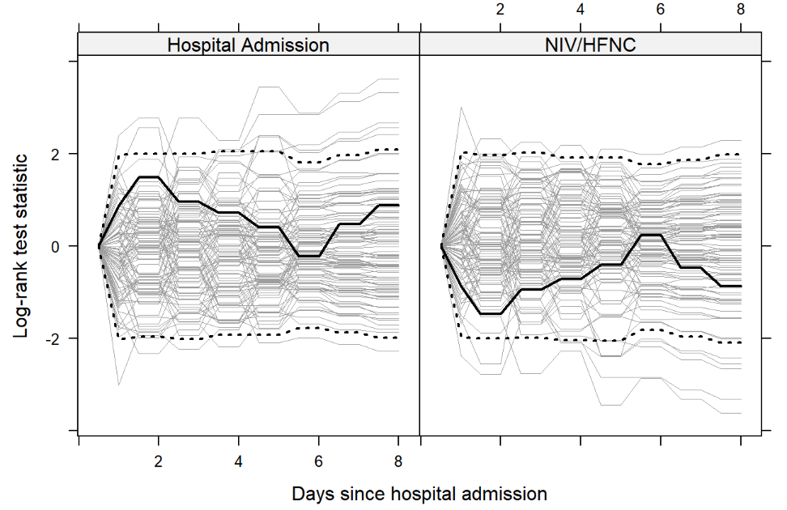